# Dataset 3 Integration

Joey Hastings

2023-05-04

# Load Packages

```r
library(tictoc)
library(tidyverse)
library(cowplot)
library(ggExtra)
library(ggthemes)
library(ggrepel)
library(splatter)
library(scater)
library(scran)
library(kableExtra)
library(grid)
library(gridExtra)
library(r.jive)
library(Seurat)
library(harmony)

library(RSpectra)
library(scRNAseq)
library(lme4)

library(kBET)    # kBET
library(cluster) # ASW
library(lisi)    # LISI

source("PVCA.R")
source("JIVE/jive_speedup.R", chdir = T)

theme_set(theme_few())

dataset_name <- "dataset3"
```

# Simulated Dataset

```r
# Parameters that remain the same for all cell types
nGenes <- 5000
method = "single"
dropout.type = "experiment"
dropout.shape = -1
verbose = FALSE

tic("Data Simulation")
sim_data <- splatSimulate(
  # Parameters to remain the same
  verbose = verbose,
  batchCells = c(500, 500),
  dropout.mid = 0.05,
  nGenes = nGenes,
  method = "groups",
  seed = 1,
  dropout.type = dropout.type,
  dropout.shape = dropout.shape,
  group.prob = c(0.6, 0.3, 0.1),
  # Parameters to tweak in each simulation
  batch.facLoc = 0.2,
  batch.facScale = 0.1,
  de.prob = c(0.01, 0.1, 0.5),
  de.downProb = c(0.01, 0.4, 0.9),
  de.facLoc = c(0.6, 1, 0.2),
  de.facScale = c(0.1, 0.4, 0.8),
  bcv.common = 1
)
toc()
```

```
## Data Simulation: 5.47 sec elapsed
```

## Cell Frequencies by Batch and Cell Cluster

```r
batch_freq <- as.data.frame(table(Batch = sim_data$Batch))
batch_cluster_freq <-
  as.data.frame(table(
    Batch = sim_data$Batch,
    Cluster = sim_data$Group
  )) %>%
  pivot_wider(id_cols = c("Batch"), names_from = "Cluster", values_from = "Freq")

batch_cluster_df <- left_join(batch_freq, batch_cluster_freq, by = "Batch")
batch_cluster_df %>%
  kbl(
    col.names = c(
      "Batch Number",
      "Total Batch Count",
      "Group 1",
      "Group 2",
      "Group 3"
    )
  ) %>%
  kable_styling() %>%
  add_header_above(c("Batch" = 2, "Cluster" = 3)) %>%
  column_spec(2, border_right = T)
```

| Batch Batch Number | Batch Total Batch Count | Cluster Group 1 | Cluster Group 2 | Cluster Group 3 |
| --- | --- | --- | --- | --- |
| Batch1 | 500 | 312 | 136 | 52 |
| Batch2 | 500 | 294 | 148 | 58 |

## Preprocess Data

No preprocessing for simulated data.

```r
# Final SCE object
data_SCE <- sim_data
colData(data_SCE)$Batch <- factor(colData(data_SCE)$Batch)
colData(data_SCE)$Cluster <- factor(colData(data_SCE)$Group)
```

## Visualize Raw Counts

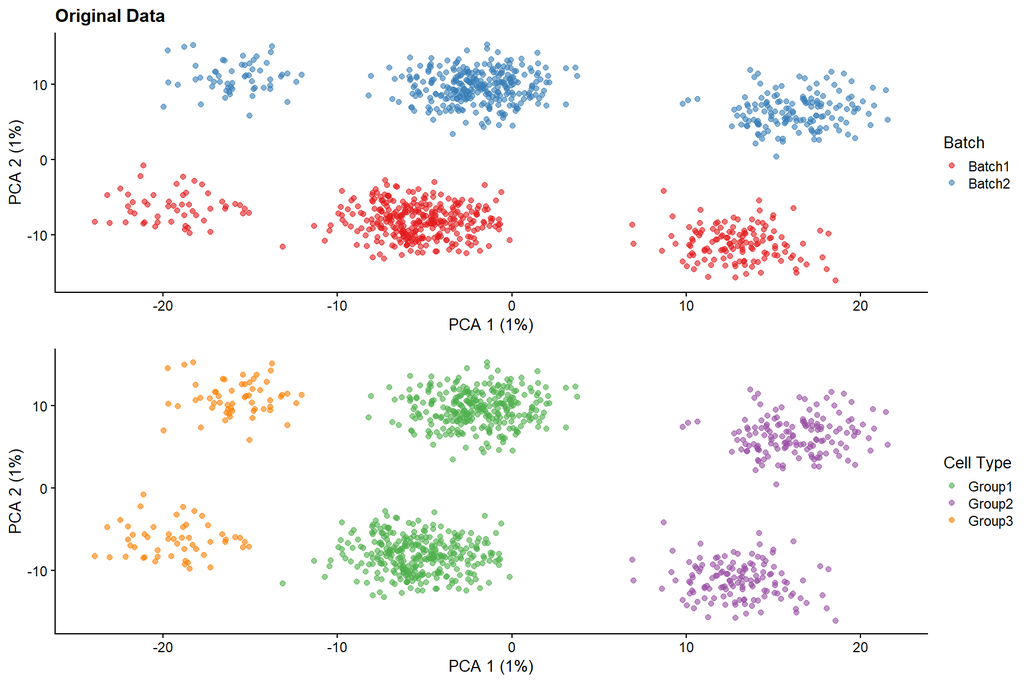

```r
data_SCE <- logNormCounts(data_SCE)

# Dimension reduction visualization
set.seed(1)
data_SCE <- runPCA(data_SCE, ncomponents = 30, ntop = 2000)
data_SCE <- runTSNE(data_SCE)
data_SCE <- runUMAP(data_SCE)

orig_title <- labs(title = "Original Data")
brew_colors <- RColorBrewer::brewer.pal(9, "Set1")
p1_options <- scale_color_manual(name = "Batch", values = brew_colors[1:2])
p2_options <- scale_color_manual(name = "Cell Type", values = brew_colors[c(3:5)])

orig_p1 <- plot_grid(
  plotPCA(data_SCE, color_by = "Batch")   + orig_title + p1_options,
  plotPCA(data_SCE, color_by = "Cluster") + p2_options,
  nrow=2, align = "v"
  )

orig_p2 <- plot_grid(
  plotTSNE(data_SCE, color_by = "Batch")   + orig_title + p1_options,
  plotTSNE(data_SCE, color_by = "Cluster") + p2_options,
  nrow=2, align = "v"
  )

orig_p3 <- plot_grid(
  plotUMAP(data_SCE, color_by = "Batch")   + orig_title + p1_options,
  plotUMAP(data_SCE, color_by = "Cluster") + p2_options,
  nrow=2, align = "v"
  )

orig_p1 # ggsave("orig_pca.png", orig_p1)
```

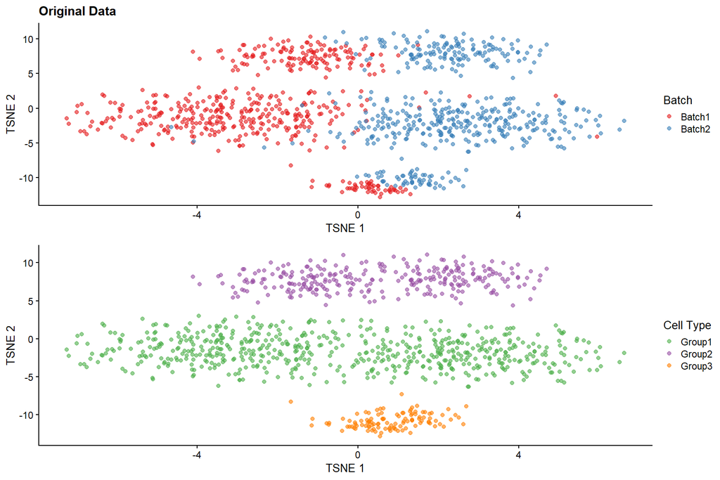

```r
orig_p2 # ggsave("orig_tsne.png", orig_p2)
```

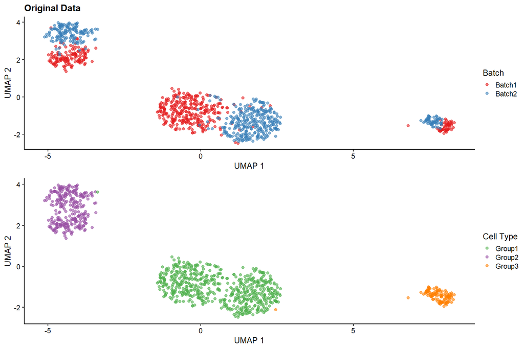

```r
orig_p3 # ggsave("orig_umap.png", orig_p3)
```

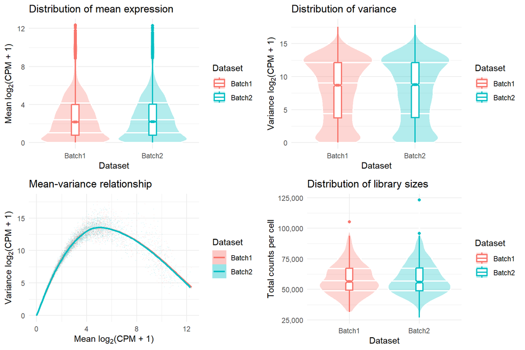

```r
comparison <- compareSCEs(
  list(
    Batch1 = data_SCE[, data_SCE$Batch == unique(data_SCE$Batch)[1]],
    Batch2 = data_SCE[, data_SCE$Batch == unique(data_SCE$Batch)[2]])
  )

plot_grid(plotlist = comparison$Plots[1:4])
```

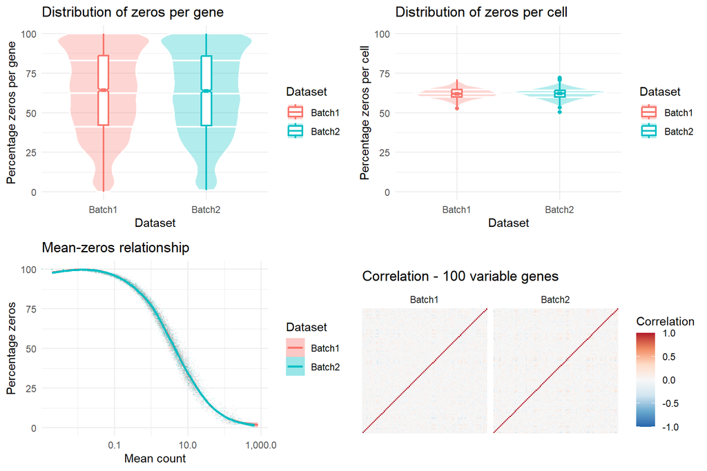

```r
plot_grid(plotlist = comparison$Plots[5:8])
```

### PVCA

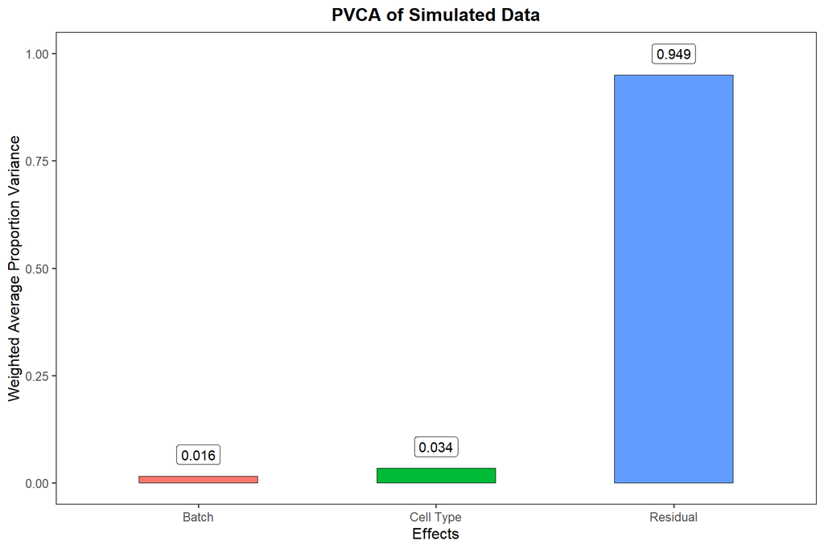

```r
batches <- data_SCE$Batch
clusters <- data_SCE$Cluster
rawcounts <- as.matrix(logcounts(data_SCE))

# Perform PVCA for 10 random samples of size 1000 (more computationally efficient)
pvca_res <- matrix(nrow = 10, ncol = 3)
meta <- cbind(Batch = batches, Cluster = clusters)

set.seed(1)
for (i in 1:10){
  sample <- sample(1:ncol(rawcounts), 1000, replace = FALSE)
  pvca_res[i, ] <- PVCA(rawcounts[, sample], meta[sample, ], threshold = 0.6, inter = FALSE)
}

# Average effect size across samples
pvca_means <- colMeans(pvca_res)

# Plot PVCA
pvca_plot <- data.frame(name = c("Batch", "Cell Type", "Residual"), values = pvca_means) %>%
  ggplot(aes(x = name, y = values)) +
  geom_col(aes(fill = name), width = 0.5, color = "black", show.legend = FALSE, linewidth = 0.25) +
  geom_label(aes(label = round(values, 3)), nudge_y = 0.05) +
  labs(x = "Effects", y = "Weighted Average Proportion Variance", title = "PVCA of Simulated Data") +
  theme(
    plot.title = element_text(face = "bold", size = rel(1.2), hjust = 0.5)
  )
pvca_plot
```

```r
ggsave("output/pvca_simdata.png", pvca_plot, width = 9, height = 4, dpi = 600)
```

# Perform Integration Methods

## JIVE

```r
method_name <- "JIVE"
```

### Run Integration Method

```r
n_batches <- length(unique(batches))
unq_batches <- sort(unique(batches))

jive_data <- NULL
all_clusters <- NULL

for (i in 1:n_batches) {
  jive_data[[as.character(unq_batches[i])]] <- t(rawcounts[, batches == unq_batches[i]])
  all_clusters[[as.character(unq_batches[i])]] <- clusters[batches == unq_batches[i]]
}

CORES <- parallel::detectCores()

tic("JIVE v2 runtime (given)")
JIVE_results <-
  jive_v2(
    jive_data,
    rankJ = 10,
    rankA = c(160, 110),
    method = "given",
    maxiter = 10000,
    CORES = CORES
  )
# JIVE v2 runtime (given): 4478.06 sec elapsed
# JIVE algorithm converged after  708  iterations.
toc()

saveRDS(JIVE_results, file = "JIVE/data/JIVE_v2_dataset3.rds")
```

Summary of estimated ranks and variance explained by joint/individual/residual for each approach:

```r
JIVE_results <- readRDS(file = "JIVE/data/JIVE_v2_dataset3.rds")
summary(JIVE_results)
```

```
## $Method
## [1] "given"
##
## $Ranks
##      Source   Rank
## [1,] "Joint"  "10"
## [2,] "Batch1" "160"
## [3,] "Batch2" "110"
##
## $Variance
##            Batch1 Batch2
## Joint       0.497  0.518
## Individual  0.253  0.166
## Residual    0.250  0.316
```

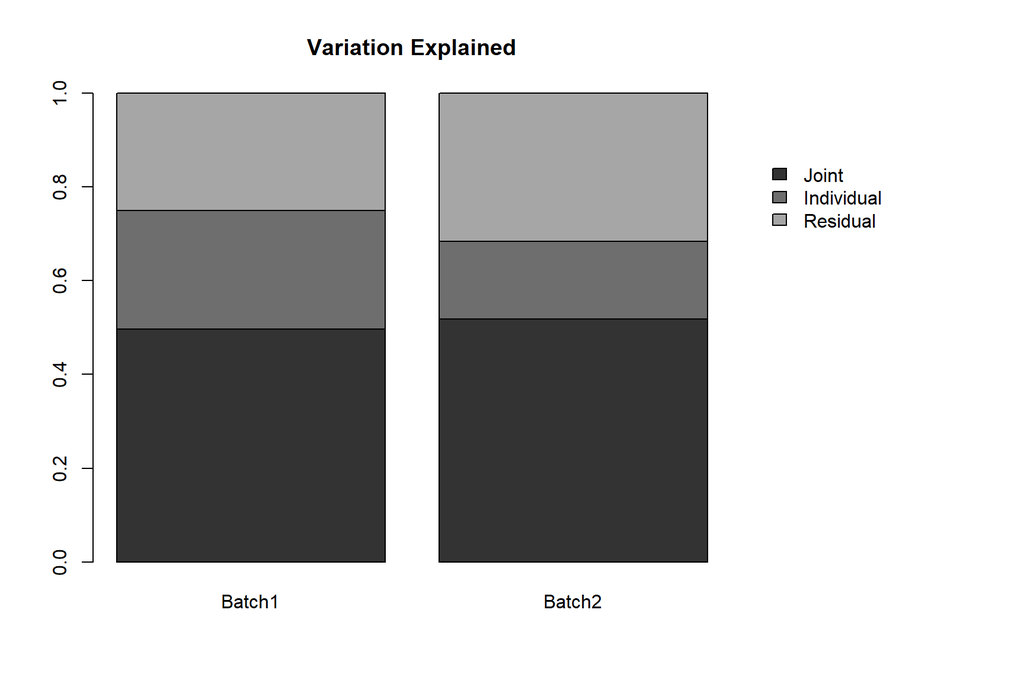

```r
plot(JIVE_results)
```

```r
joint <- do.call(rbind, JIVE_results$joint)
jive_final <- joint
```

### Visualization of Integration

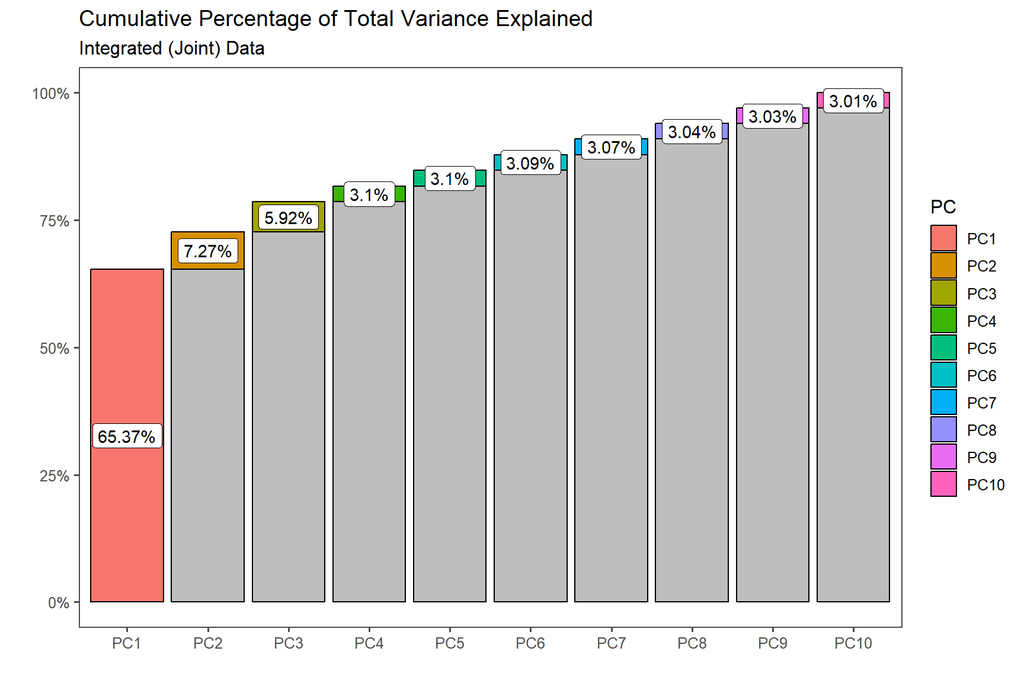

```r
joint_svd <- svds(joint, k = JIVE_results$rankJ)

var_explained <- data.frame(
  sv = joint_svd$d,
  cum_sv = cumsum(joint_svd$d),
  tot_sv = sum(joint_svd$d)
  ) %>%
  mutate(
    pct_sv = sv / tot_sv,
    cumpct_sv = cum_sv / tot_sv,
    PC = paste0("PC", row_number()),
    PC = factor(PC, levels = paste0("PC", row_number()))
  )

var_explained %>%
  ggplot(aes(x = PC)) +
  geom_col(aes(y = cumpct_sv, fill = PC), color = "black") +
  geom_col(aes(y = cumpct_sv - pct_sv), fill = "gray", color = "black") +
  geom_label(aes(y = cumpct_sv - (pct_sv / 2), label = paste0(round(pct_sv * 100, 2), "%"))) +
  scale_y_continuous(labels = scales::percent) +
  labs(
    x = "", y = "",
    title = "Cumulative Percentage of Total Variance Explained",
    subtitle = "Integrated (Joint) Data"
  )
```

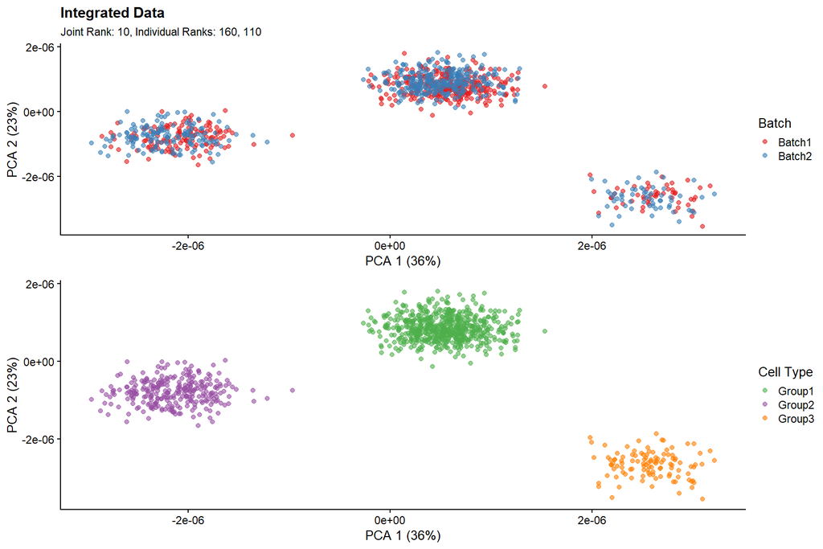

```r
jive_integrated <- SingleCellExperiment(list(logcounts = t(jive_final)))
colData(jive_integrated)$Batch <- batches
colData(jive_integrated)$Cluster <- clusters

set.seed(1)
# Original PCA based on joint matrices for each batch
jive_integrated <- runPCA(jive_integrated, ncomponents = 30, ntop = 2000)

# t-SNE based on original PC
jive_integrated <- runTSNE(jive_integrated)

# UMAP based on original PC
jive_integrated <- runUMAP(jive_integrated)

plot_title <- labs(
    title = "Integrated Data",
    subtitle = paste0(
      "Joint Rank: ",
      JIVE_results$rankJ,
      ", Individual Ranks: ",
      paste(JIVE_results$rankA, collapse = ", ")
    )
  )

# PCA
jive_pca <- plot_grid(
  plotPCA(jive_integrated, color_by = "Batch")   + plot_title + p1_options,
  plotPCA(jive_integrated, color_by = "Cluster") + p2_options,
  nrow = 2, align = "v"
  )

# jive_pca_2_3 <- plot_grid(
#   plotPCA(jive_integrated, color_by = "Batch",   ncomponents = 2:3) + plot_title + p1_options,
#   plotPCA(jive_integrated, color_by = "Cluster", ncomponents = 2:3) + p2_options,
#   nrow = 2, align = "v"
#   )
#
# jive_pca_3_4 <- plot_grid(
#   plotPCA(jive_integrated, color_by = "Batch",   ncomponents = 3:4) + plot_title + p1_options,
#   plotPCA(jive_integrated, color_by = "Cluster", ncomponents = 3:4) + p2_options,
#   nrow = 2, align = "v"
#   )
#
# jive_pca_4_5 <- plot_grid(
#   plotPCA(jive_integrated, color_by = "Batch",   ncomponents = 4:5) + plot_title + p1_options,
#   plotPCA(jive_integrated, color_by = "Cluster", ncomponents = 4:5) + p2_options,
#   nrow = 2, align = "v"
#   )

# t-SNE
jive_tsne <- plot_grid(
  plotTSNE(jive_integrated, color_by = "Batch")   + p1_options,
  plotTSNE(jive_integrated, color_by = "Cluster") + p2_options,
  nrow = 2, align = "v"
  )

# UMAP
jive_umap <- plot_grid(
  plotUMAP(jive_integrated, color_by = "Batch")   + p1_options,
  plotUMAP(jive_integrated, color_by = "Cluster") + p2_options,
  nrow = 2, align = "v"
  )

jive_pca
```

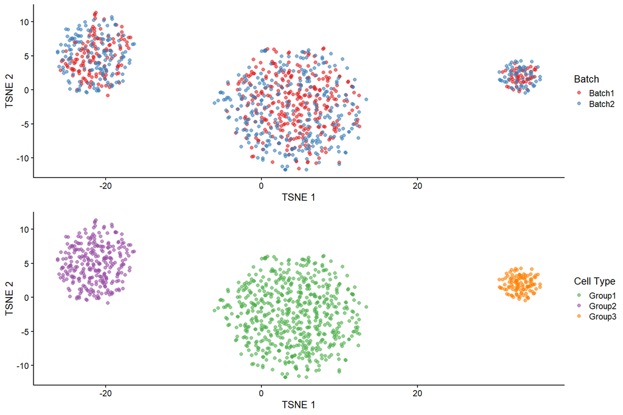

```r
jive_tsne
```

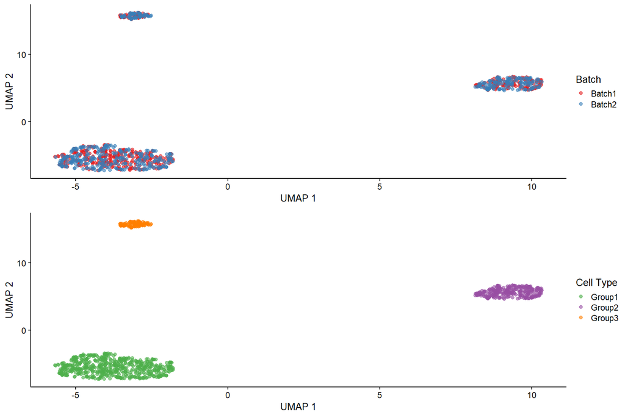

```r
jive_umap
```

### kBET

```r
# data: a matrix (rows: samples, columns: features (genes))
jive_svd <- svds(jive_final, k = 30)
data <- jive_svd$u %*% diag(jive_svd$d)

# batch: vector or factor with batch label of each cell
batch <- batches

sample_size <- seq(0.05, 0.25, by = 0.05)
rejection_rate <- list()

set.seed(1)
for (i in 1:length(sample_size)) {
  k <- floor(nrow(data) * sample_size[i])

  cat("\nSample Size: ", sample_size[i], ", k = ", k, "\n", sep = "")
  cat("------------------------------\n")

  batch.estimate <- kBET(data, batch, k0 = k, plot = F, do.pca = F, verbose = T)

  cat("\n------------------------------\n")

  if (class(batch.estimate) == "list") {
    rejection_rate[[i]] <- batch.estimate$summary %>%
      rownames_to_column(var = "statistic") %>%
      mutate(sample_size = sample_size[i]) %>%
      select(sample_size, statistic, kBET_rr = kBET.observed)
  }
}
```

```
##
## Sample Size: 0.05, k = 50
## ------------------------------
## finding knns...done. Time:
##    user  system elapsed
##    0.06    0.00    0.06
## Number of kBET tests is set to 100.
##
## ------------------------------
##
## Sample Size: 0.1, k = 100
## ------------------------------
## finding knns...done. Time:
##    user  system elapsed
##    0.08    0.00    0.08
## Number of kBET tests is set to 100.
##
## ------------------------------
##
## Sample Size: 0.15, k = 150
## ------------------------------
## finding knns...done. Time:
##    user  system elapsed
##    0.09    0.00    0.09
## Number of kBET tests is set to 100.
##
## ------------------------------
##
## Sample Size: 0.2, k = 200
## ------------------------------
## finding knns...done. Time:
##    user  system elapsed
##    0.14    0.00    0.14
## Number of kBET tests is set to 100.
##
## ------------------------------
##
## Sample Size: 0.25, k = 250
## ------------------------------
## finding knns...done. Time:
##    user  system elapsed
##    0.16    0.00    0.15
## Number of kBET tests is set to 100.
##
## ------------------------------
```

```r
jive_kbet <- bind_rows(rejection_rate) %>%
  mutate(Method = method_name) %>%
  pivot_wider(
    id_cols = c("Method", "sample_size"),
    names_from = "statistic",
    values_from = "kBET_rr"
  ) %>%
  select(Method, sample_size, median_rr = `50%`)

jive_kbet %>% write_csv(file = paste0("output/", method_name, "_", dataset_name, "_kBET.csv"))
```

### Average Silhouette Width

Original batch label and cell types/groups will be considered the clusters to compute $ASW_{batch}$ and $ASW_{group}$

- Compute average silhouette width (ASW) for the first 30 PCs of 80% sub-sample of joint data
  - ASW ranges between -1 and 1
  - Values **close to 1** indicate the cell is well-matched to its cluster (i.e., batch label)
  - Values **close to -1** indicate the cell is **not** well-matched to its cluster (i.e., batch label)
    - We hope to see lower values for $ASW_{batch}$ since it is indicative of well-mixed batches
    - We hope to see higher values for $ASW_{group}$ since it is indicative that distinct cell groups were preserved after batch-mixing
- Repeat `20` times
- Calculate the median ASW from the `20` runs to ensure stability of the measurement

```r
asw_repeat <- 20
npcs <- 30

asw_batch <- list()
asw_cluster <- list()
subset_prop <- 0.8 # subsample to 80% of the data
subset_size_total <- floor(length(batch) * subset_prop)

jive_pc <- jive_svd$u %*% diag(jive_svd$d)

for (i in 1:asw_repeat) {
  set.seed(i)
  subset_index <-
    data.frame(index = 1:length(batch) , batch = batch) %>%
    slice_sample(n = subset_size_total, replace = F)

  subset_id <- subset_index %>%
    pull(index)

  data_pc <- jive_pc[subset_id, ]

  dissimilarity_matrix <- daisy(data_pc)

  asw_batch_i <- silhouette(as.integer(factor(batches[subset_id])), dissimilarity_matrix)
  asw_batch[[i]] <- as.data.frame(rbind(summary(asw_batch_i)[["si.summary"]]))

  asw_cluster_i <- silhouette(as.integer(factor(clusters[subset_id])), dissimilarity_matrix)
  asw_cluster[[i]] <- as.data.frame(rbind(summary(asw_cluster_i)[["si.summary"]]))
}

jive_asw <- bind_rows(
  bind_rows(asw_batch) %>% mutate(Label = "Batch"),
  bind_rows(asw_cluster) %>% mutate(Label = "Cluster")
  ) %>%
  mutate(Method = method_name) %>%
  select(Method, Label, Mean)

jive_asw %>% write_csv(file = paste0("output/", method_name, "_", dataset_name, "_ASW.csv"))
```

### LISI Scores

```r
# Performed for all cells
jive_lisi <-
  compute_lisi(
    jive_pc,
    data.frame(Batch = batches, Cluster = clusters),
    c("Batch", "Cluster"),
    perplexity = 40
  ) %>%
  pivot_longer(
    cols = c("Batch", "Cluster"),
    names_to = "Label",
    values_to = "LISI"
  ) %>%
  mutate(Method = method_name)

jive_lisi %>%
  write_csv(file = paste0("output/", method_name, "_", dataset_name, "_LISI.csv"))
```

## Seurat v3

```r
method_name <- "Seurat"

# Create Seurat object list so all data is preprocessed in the same manner
sim_metadata <- as.data.frame(colData(data_SCE))
sim_seurat <- CreateSeuratObject(counts(data_SCE), meta.data = sim_metadata)

#################
# Identify HVGs #
#################

# split the dataset into a list of seurat objects (one for each batch)
sim_seurat_batch <- SplitObject(sim_seurat, split.by = "Batch")

# normalize and identify variable features for each dataset independently
sim_seurat_batch <- lapply(X = sim_seurat_batch, FUN = function(x) {
  x <- NormalizeData(x)
  x <- FindVariableFeatures(x, selection.method = "vst", nfeatures = 5000)
})

# select features that are repeatedly variable across datasets for integration
features <- SelectIntegrationFeatures(object.list = sim_seurat_batch, nfeatures = 5000)
```

### Run Integration Method

- Perform integration by finding a set of anchors from the two batches (via CCA)
- Use the anchor list to integrate the two batches

```r
anchors <- FindIntegrationAnchors(object.list = sim_seurat_batch, anchor.features = features)
```

```
## Scaling features for provided objects
```

```
## Finding all pairwise anchors
```

```
## Running CCA
```

```
## Merging objects
```

```
## Finding neighborhoods
```

```
## Finding anchors
```

```
##  Found 1949 anchors
```

```
## Filtering anchors
```

```
##  Retained 1136 anchors
```

```r
seurat_integrated <- IntegrateData(anchorset = anchors)
```

```
## Merging dataset 2 into 1
```

```
## Extracting anchors for merged samples
```

```
## Finding integration vectors
```

```
## Finding integration vector weights
```

```
## Integrating data
```

```r
GetAssay(seurat_integrated, "integrated")
```

```
## Assay data with 4949 features for 1000 cells
## Top 10 variable features:
##  Gene3835, Gene1022, Gene4384, Gene4030, Gene2891, Gene1852, Gene1621,
## Gene3611, Gene552, Gene3066
```

- Integrated/combined data is centered/scaled
- First 30 PCs are computed/stored
- PC1-PC30 are used to perform t-SNE and UMAP dimensionality reduction
- Calculates k-nearest neighbors (`k = 20` by default) from PC1-PC30
- Identify clusters by using Shared Nearest Neighbors (SNN):
  - “First calculate k-nearest neighbors and construct the SNN graph”
  - “Then optimize the modularity function to determine clusters”

```r
# specify that we will perform downstream analysis on the corrected data note that the
# original unmodified data still resides in the 'RNA' assay
DefaultAssay(seurat_integrated) <- "integrated"

# Run the standard workflow for visualization and clustering
set.seed(1)
seurat_integrated <- ScaleData(seurat_integrated, verbose = FALSE)
seurat_integrated <- RunPCA(seurat_integrated, verbose = FALSE, npcs = 30)
seurat_integrated <- RunTSNE(seurat_integrated, reduction = "pca", dims = 1:30)
seurat_integrated <- RunUMAP(seurat_integrated, reduction = "pca", dims = 1:30)
seurat_integrated <- FindNeighbors(seurat_integrated, reduction = "pca", dims = 1:30)
seurat_integrated <- FindClusters(seurat_integrated, resolution = 0.5)
```

```
## Modularity Optimizer version 1.3.0 by Ludo Waltman and Nees Jan van Eck
##
## Number of nodes: 1000
## Number of edges: 102464
##
## Running Louvain algorithm...
## Maximum modularity in 10 random starts: 0.7553
## Number of communities: 3
## Elapsed time: 0 seconds
```

```r
seurat_integrated <- AddMetaData(seurat_integrated, factor(seurat_integrated$Batch), col.name = "Batch")
seurat_integrated <- AddMetaData(seurat_integrated, factor(seurat_integrated$Cluster), col.name = "Cluster")

seurat_final <- t(seurat_integrated@assays$integrated@scale.data)
```

### Visualization of Integration

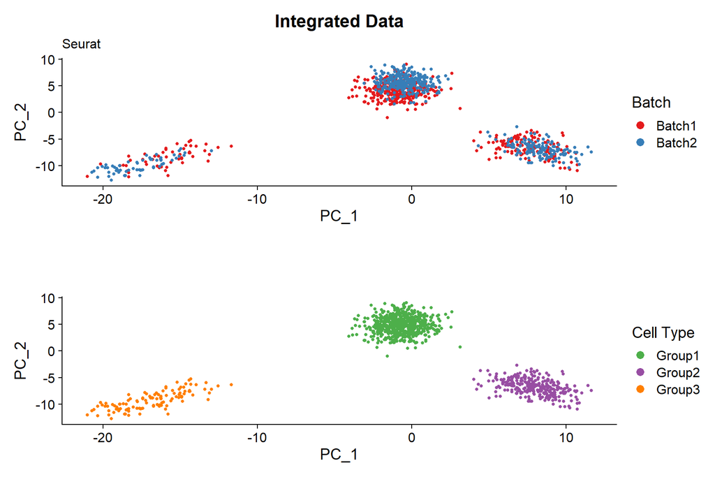

```r
plot_title <- labs(
    title = "Integrated Data",
    subtitle = method_name
  )

# PCA
seurat_pca <- plot_grid(
  PCAPlot(seurat_integrated, group.by = "Batch")   + plot_title  + p1_options,
  PCAPlot(seurat_integrated, group.by = "Cluster") + ggtitle("") + p2_options,
  nrow = 2, align = "vh"
  )

# t-SNE
seurat_tsne <- plot_grid(
  TSNEPlot(seurat_integrated, group.by = "Batch")   + plot_title  + p1_options,
  TSNEPlot(seurat_integrated, group.by = "Cluster") + ggtitle("") + p2_options,
  nrow = 2, align = "vh"
  )

# UMAP
seurat_umap <- plot_grid(
  UMAPPlot(seurat_integrated, group.by = "Batch")   + plot_title  + p1_options,
  UMAPPlot(seurat_integrated, group.by = "Cluster") + ggtitle("") + p2_options,
  nrow = 2, align = "vh"
  )

seurat_pca
```

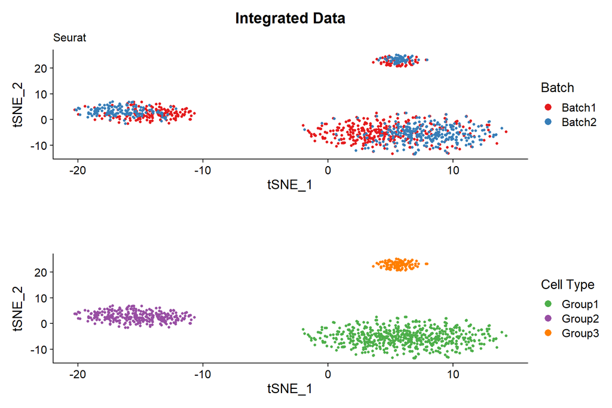

```r
seurat_tsne
```

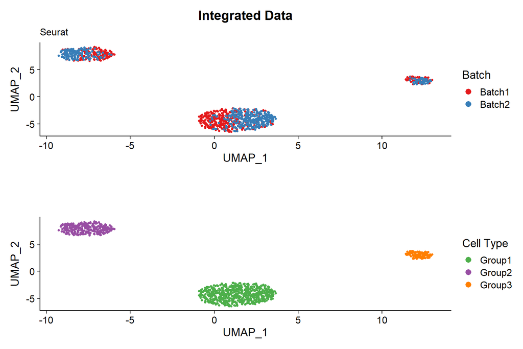

```r
seurat_umap
```

### kBET

```r
# data: a matrix (rows: samples, columns: features (genes))
data <- Embeddings(seurat_integrated)

# batch: vector or factor with batch label of each cell
batch <- batches

sample_size <- seq(0.05, 0.25, by = 0.05)
rejection_rate <- list()

set.seed(1)
for (i in 1:length(sample_size)) {
  k <- floor(nrow(data) * sample_size[i])

  cat("\nSample Size: ", sample_size[i], ", k = ", k, "\n", sep = "")
  cat("------------------------------\n")

  batch.estimate <- kBET(data, batch, k0 = k, plot = F, do.pca = F, verbose = T)

  cat("\n------------------------------\n")

  if (class(batch.estimate) == "list") {
    rejection_rate[[i]] <- batch.estimate$summary %>%
      rownames_to_column(var = "statistic") %>%
      mutate(sample_size = sample_size[i]) %>%
      select(sample_size, statistic, kBET_rr = kBET.observed)
  }
}
```

```
##
## Sample Size: 0.05, k = 50
## ------------------------------
## finding knns...done. Time:
##    user  system elapsed
##    0.08    0.00    0.08
## Number of kBET tests is set to 100.
## There are 62 cells (6.2%) that do not appear in any neighbourhood.
## The expected frequencies for each category have been adapted.
## Cell indexes are saved to result list.
##
## ------------------------------
##
## Sample Size: 0.1, k = 100
## ------------------------------
## finding knns...done. Time:
##    user  system elapsed
##    0.08    0.00    0.08
## Number of kBET tests is set to 100.
## There are 29 cells (2.9%) that do not appear in any neighbourhood.
## The expected frequencies for each category have been adapted.
## Cell indexes are saved to result list.
##
## ------------------------------
##
## Sample Size: 0.15, k = 150
## ------------------------------
## finding knns...done. Time:
##    user  system elapsed
##    0.11    0.00    0.11
## Number of kBET tests is set to 100.
## No outsiders found.
## ------------------------------
##
## Sample Size: 0.2, k = 200
## ------------------------------
## finding knns...done. Time:
##    user  system elapsed
##    0.12    0.00    0.13
## Number of kBET tests is set to 100.
## No outsiders found.
## ------------------------------
##
## Sample Size: 0.25, k = 250
## ------------------------------
## finding knns...done. Time:
##    user  system elapsed
##    0.14    0.00    0.14
## Number of kBET tests is set to 100.
## No outsiders found.
## ------------------------------
```

```r
seurat_kbet <- bind_rows(rejection_rate) %>%
  mutate(Method = method_name) %>%
  pivot_wider(
    id_cols = c("Method", "sample_size"),
    names_from = "statistic",
    values_from = "kBET_rr"
  ) %>%
  select(Method, sample_size, median_rr = `50%`)

seurat_kbet %>% write_csv(file = paste0("output/", method_name, "_", dataset_name, "_kBET.csv"))
```

### Average Silhouette Width

```r
asw_repeat <- 20
npcs <- 30

asw_batch <- list()
asw_cluster <- list()
subset_prop <- 0.8 # subsample to 80% of the data
subset_size_total <- floor(length(batch) * subset_prop)

seurat_pc <- Embeddings(seurat_integrated)

for (i in 1:asw_repeat) {
  set.seed(i)
  subset_index <-
    data.frame(index = 1:length(batch) , batch = batch) %>%
    slice_sample(n = subset_size_total, replace = F)

  subset_id <- subset_index %>%
    pull(index)

  data_pc <- seurat_pc[subset_id, ]

  dissimilarity_matrix <- daisy(data_pc)

  asw_batch_i <- silhouette(as.integer(factor(batches[subset_id])), dissimilarity_matrix)
  asw_batch[[i]] <- as.data.frame(rbind(summary(asw_batch_i)[["si.summary"]]))

  asw_cluster_i <- silhouette(as.integer(factor(clusters[subset_id])), dissimilarity_matrix)
  asw_cluster[[i]] <- as.data.frame(rbind(summary(asw_cluster_i)[["si.summary"]]))
}

seurat_asw <- bind_rows(
  bind_rows(asw_batch) %>% mutate(Label = "Batch"),
  bind_rows(asw_cluster) %>% mutate(Label = "Cluster")
  ) %>%
  mutate(Method = method_name) %>%
  select(Method, Label, Mean)

seurat_asw %>% write_csv(file = paste0("output/", method_name, "_", dataset_name, "_ASW.csv"))
```

### LISI Scores

```r
# Performed for all cells
seurat_lisi <-
  compute_lisi(
    seurat_pc,
    data.frame(Batch = batches, Cluster = clusters),
    c("Batch", "Cluster"),
    perplexity = 40
  ) %>%
  pivot_longer(
    cols = c("Batch", "Cluster"),
    names_to = "Label",
    values_to = "LISI"
  ) %>%
  mutate(Method = method_name)

seurat_lisi %>%
  write_csv(file = paste0("output/", method_name, "_", dataset_name, "_LISI.csv"))
```

## Harmony

```r
method_name <- "Harmony"
```

### Run Integration Method

```r
harmony_integrated <-
  runPCA(
    data_SCE,
    ncomponents = 30,
    ntop = nrow(data_SCE)
  )
harmony_integrated <-
  RunHarmony(
    harmony_integrated,
    "Batch",
    max.iter.harmony = 20
  )
```

```
## Harmony 1/20
```

```
## Harmony 2/20
```

```
## Harmony 3/20
```

```
## Harmony converged after 3 iterations
```

```r
harmony_integrated <- runTSNE(harmony_integrated, dimred = "HARMONY")
harmony_integrated <- runUMAP(harmony_integrated, dimred = "HARMONY")

harmony_final <- reducedDim(harmony_integrated, "HARMONY")
```

### Visualization of Integration

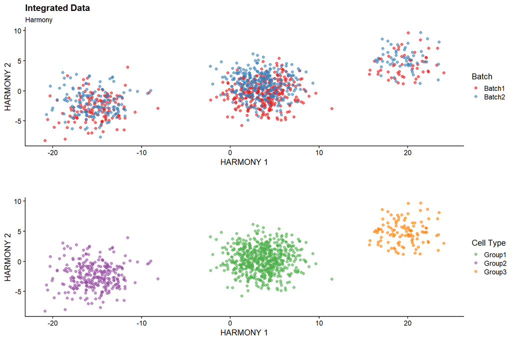

```r
plot_title <- labs(title = "Integrated Data", subtitle = method_name)

# Harmony PCA
harmony_pca <- plot_grid(
  plotReducedDim(harmony_integrated, dimred = "HARMONY",
    color_by = "Batch",   ncomponents = 1:2 ) + plot_title + p1_options,
  plotReducedDim(harmony_integrated, dimred = "HARMONY",
    color_by = "Cluster", ncomponents = 1:2 ) + p2_options,
  nrow = 2, align = "vh"
  )
# t-SNE
harmony_tsne <- plot_grid(
  plotTSNE(harmony_integrated, color_by = "Batch")   + plot_title + p1_options,
  plotTSNE(harmony_integrated, color_by = "Cluster") + p2_options,
  nrow = 2, align = "vh"
  )
# UMAP
harmony_umap <- plot_grid(
  plotUMAP(harmony_integrated, color_by = "Batch")   + plot_title + p1_options,
  plotUMAP(harmony_integrated, color_by = "Cluster") + p2_options,
  nrow = 2, align = "vh"
  )
harmony_pca
```

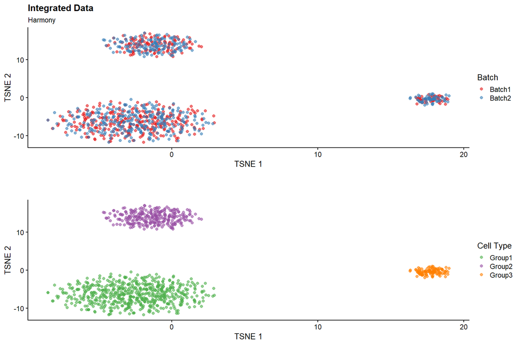

```r
harmony_tsne
```

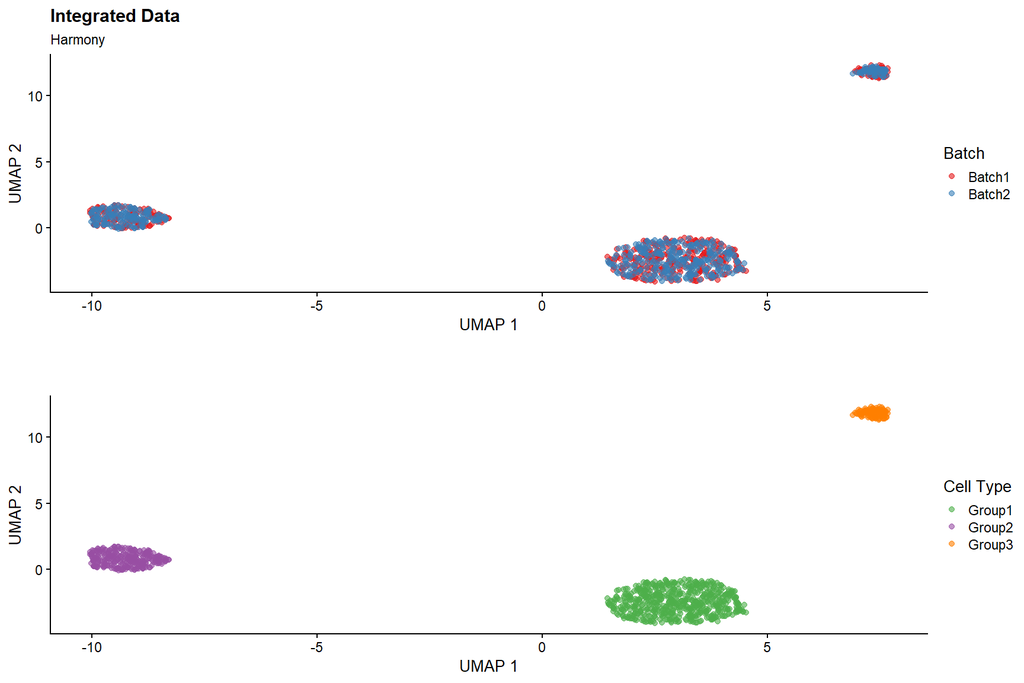

```r
harmony_umap
```

### kBET

```r
# data: a matrix (rows: samples, columns: features (genes))
data <- harmony_final[, 1:30]

# batch: vector or factor with batch label of each cell
batch <- batches

sample_size <- seq(0.05, 0.25, by = 0.05)
rejection_rate <- list()

set.seed(1)
for (i in 1:length(sample_size)) {
  k <- floor(nrow(data) * sample_size[i])

  cat("\nSample Size: ", sample_size[i], ", k = ", k, "\n", sep = "")
  cat("------------------------------\n")

  batch.estimate <- kBET(data, batch, k0 = k, plot = F, do.pca = F, verbose = T)

  cat("\n------------------------------\n")

  if (class(batch.estimate) == "list") {
    rejection_rate[[i]] <- batch.estimate$summary %>%
      rownames_to_column(var = "statistic") %>%
      mutate(sample_size = sample_size[i]) %>%
      select(sample_size, statistic, kBET_rr = kBET.observed)
  }
}
```

```
##
## Sample Size: 0.05, k = 50
## ------------------------------
## finding knns...done. Time:
##    user  system elapsed
##    0.06    0.00    0.07
## Number of kBET tests is set to 100.
## No outsiders found.
## ------------------------------
##
## Sample Size: 0.1, k = 100
## ------------------------------
## finding knns...done. Time:
##    user  system elapsed
##    0.10    0.00    0.09
## Number of kBET tests is set to 100.
## No outsiders found.
## ------------------------------
##
## Sample Size: 0.15, k = 150
## ------------------------------
## finding knns...done. Time:
##    user  system elapsed
##    0.11    0.00    0.11
## Number of kBET tests is set to 100.
## No outsiders found.
## ------------------------------
##
## Sample Size: 0.2, k = 200
## ------------------------------
## finding knns...done. Time:
##    user  system elapsed
##    0.11    0.00    0.11
## Number of kBET tests is set to 100.
##
## ------------------------------
##
## Sample Size: 0.25, k = 250
## ------------------------------
## finding knns...done. Time:
##    user  system elapsed
##    0.14    0.00    0.14
## Number of kBET tests is set to 100.
##
## ------------------------------
```

```r
harmony_kbet <- bind_rows(rejection_rate) %>%
  mutate(Method = method_name) %>%
  pivot_wider(
    id_cols = c("Method", "sample_size"),
    names_from = "statistic",
    values_from = "kBET_rr"
  ) %>%
  select(Method, sample_size, median_rr = `50%`)

harmony_kbet %>% write_csv(file = paste0("output/", method_name, "_", dataset_name, "_kBET.csv"))
```

### Average Silhouette Width

```r
asw_repeat <- 20
npcs <- 30

asw_batch <- list()
asw_cluster <- list()
subset_prop <- 0.8 # subsample to 80% of the data
subset_size_total <- floor(length(batch) * subset_prop)

harmony_pc <- harmony_final[, 1:30]

for (i in 1:asw_repeat) {
  set.seed(i)
  subset_index <-
    data.frame(index = 1:length(batch) , batch = batch) %>%
    slice_sample(n = subset_size_total, replace = F)

  subset_id <- subset_index %>%
    pull(index)

  data_pc <- harmony_pc[subset_id, ]

  dissimilarity_matrix <- daisy(data_pc)

  asw_batch_i <- silhouette(as.integer(factor(batches[subset_id])), dissimilarity_matrix)
  asw_batch[[i]] <- as.data.frame(rbind(summary(asw_batch_i)[["si.summary"]]))

  asw_cluster_i <- silhouette(as.integer(factor(clusters[subset_id])), dissimilarity_matrix)
  asw_cluster[[i]] <- as.data.frame(rbind(summary(asw_cluster_i)[["si.summary"]]))
}

harmony_asw <- bind_rows(
  bind_rows(asw_batch) %>% mutate(Label = "Batch"),
  bind_rows(asw_cluster) %>% mutate(Label = "Cluster")
  ) %>%
  mutate(Method = method_name) %>%
  select(Method, Label, Mean)

harmony_asw %>% write_csv(file = paste0("output/", method_name, "_", dataset_name, "_ASW.csv"))
```

### LISI Scores

```r
# Performed for all cells
harmony_lisi <-
  compute_lisi(
    harmony_pc,
    data.frame(Batch = batches, Cluster = clusters),
    c("Batch", "Cluster"),
    perplexity = 40
  ) %>%
  pivot_longer(
    cols = c("Batch", "Cluster"),
    names_to = "Label",
    values_to = "LISI"
  ) %>%
  mutate(Method = method_name)

harmony_lisi %>%
  write_csv(file = paste0("output/", method_name, "_", dataset_name, "_LISI.csv"))
```

# Integration Method Comparison

```r
method_lvl <- c("JIVE", "Seurat", "Harmony", "Raw")
```

## t-SNE Plots

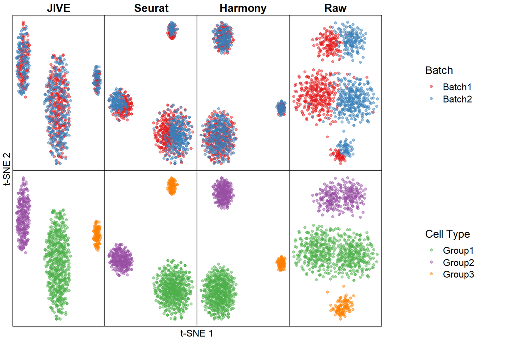

```r
# JIVE
jive_tsne_df <- reducedDim(jive_integrated, "TSNE") %>%
  as.data.frame() %>%
  mutate(Method = "JIVE") %>%
  mutate(Batch = batches, Cluster = clusters)

jive_tsne_batch <- jive_tsne_df %>%
  ggplot(aes(x = V1, y = V2, color = Batch)) +
  geom_point(alpha = 0.5) +
  theme_nothing() +
  theme(
    plot.title = element_text(hjust = 0.5, face = "bold"),
    legend.position = "right",
    plot.background = element_rect(color = "black")
  ) +
  p1_options

jive_tsne_cluster <- jive_tsne_df %>%
  ggplot(aes(x = V1, y = V2, color = Cluster)) +
  geom_point(alpha = 0.5) +
  theme_nothing() +
  theme(
    legend.position = "right",
    plot.background = element_rect(color = "black")
  ) +
  p2_options

jive_title <- ggdraw() + draw_label("JIVE", fontface = "bold")

jive_tsne_plot <- plot_grid(
  jive_title,
  jive_tsne_batch + theme(legend.position = "none"),
  jive_tsne_cluster + theme(legend.position = "none"),
  ncol = 1, align = "hv", rel_heights=c(0.1, 1, 1)
)

# Seurat
seurat_tsne_df <- Embeddings(seurat_integrated, "tsne") %>%
  as.data.frame() %>%
  mutate(Method = "Seurat") %>%
  mutate(Batch = batches, Cluster = clusters)

seurat_tsne_batch <- seurat_tsne_df %>%
  ggplot(aes(x = tSNE_1, y = tSNE_2, color = Batch)) +
  geom_point(alpha = 0.5) +
  theme_nothing() +
  theme(
    plot.title = element_text(hjust = 0.5, face = "bold"),
    legend.position = "right",
    plot.background = element_rect(color = "black")
  ) +
  p1_options

seurat_tsne_cluster <- seurat_tsne_df %>%
  ggplot(aes(x = tSNE_1, y = tSNE_2, color = Cluster)) +
  geom_point(alpha = 0.5) +
  theme_nothing() +
  theme(
    legend.position = "right",
    plot.background = element_rect(color = "black")
  ) +
  p2_options

seurat_title <- ggdraw() + draw_label("Seurat", fontface = "bold")

seurat_tsne_plot <- plot_grid(
  seurat_title,
  seurat_tsne_batch + theme(legend.position = "none"),
  seurat_tsne_cluster + theme(legend.position = "none"),
  ncol = 1, align = "hv", rel_heights = c(0.1, 1, 1)
)

# Harmony
harmony_tsne_df <- reducedDim(harmony_integrated, "TSNE") %>%
  as.data.frame() %>%
  mutate(Method = "Harmony") %>%
  mutate(Batch = batches, Cluster = clusters)

harmony_tsne_batch <- harmony_tsne_df %>%
  ggplot(aes(x = V1, y = V2, color = Batch)) +
  geom_point(alpha = 0.5) +
  theme_nothing() +
  theme(
    plot.title = element_text(hjust = 0.5, face = "bold"),
    legend.position = "right",
    plot.background = element_rect(color = "black")
  ) +
  p1_options

harmony_tsne_cluster <- harmony_tsne_df %>%
  ggplot(aes(x = V1, y = V2, color = Cluster)) +
  geom_point(alpha = 0.5) +
  theme_nothing() +
  theme(
    legend.position = "right",
    plot.background = element_rect(color = "black")
  ) +
  p2_options

harmony_title <- ggdraw() + draw_label("Harmony", fontface = "bold")

harmony_tsne_plot <- plot_grid(
  harmony_title,
  harmony_tsne_batch + theme(legend.position = "none"),
  harmony_tsne_cluster + theme(legend.position = "none"),
  ncol = 1, align = "hv", rel_heights=c(0.1, 1, 1)
)

# Raw
raw_tsne_df <- reducedDim(data_SCE, "TSNE") %>%
  as.data.frame() %>%
  mutate(Method = "Raw") %>%
  mutate(Batch = batches, Cluster = clusters)

raw_tsne_batch <- raw_tsne_df %>%
  ggplot(aes(x = V1, y = V2, color = Batch)) +
  geom_point(alpha = 0.5) +
  theme_nothing() +
  theme(
    plot.title = element_text(hjust = 0.5, face = "bold"),
    legend.position = "right",
    plot.background = element_rect(color = "black")
  ) +
  p1_options

raw_tsne_cluster <- raw_tsne_df %>%
  ggplot(aes(x = V1, y = V2, color = Cluster)) +
  geom_point(alpha = 0.5) +
  theme_nothing() +
  theme(
    legend.position = "right",
    plot.background = element_rect(color = "black")
  ) +
  p2_options

raw_title <- ggdraw() + draw_label("Raw", fontface = "bold")

raw_tsne_plot <- plot_grid(
  raw_title,
  raw_tsne_batch + theme(legend.position = "none"),
  raw_tsne_cluster + theme(legend.position = "none"),
  ncol = 1, align = "hv", rel_heights=c(0.1, 1, 1)
)

# All
legend_batch <- get_legend(
  # create some space to the left of the legend
  jive_tsne_batch + theme(legend.box.margin = margin(0, 0, 0, 12))
)

legend_cluster <- get_legend(
  # create some space to the left of the legend
  jive_tsne_cluster + theme(legend.box.margin = margin(0, 0, 0, 12))
)

tsne_prow <- plot_grid(
  jive_tsne_plot,
  seurat_tsne_plot,
  harmony_tsne_plot,
  raw_tsne_plot,
  nrow = 1,
  hjust = -1
  )

tsne_prow_grob <- arrangeGrob(
  tsne_prow,
  left = textGrob("t-SNE 2", rot = 90),
  bottom = textGrob("t-SNE 1")
)

tsne_legend_both <- plot_grid(legend_batch, legend_cluster, nrow = 2, align = "v")

all_tsne_plot <- plot_grid(tsne_prow_grob, tsne_legend_both, rel_widths = c(3, 1))

all_tsne_plot
```

```r
ggsave("output/tsne_simdata.png", all_tsne_plot, width = 9, height = 4, dpi = 600)
```

## UMAP Plots

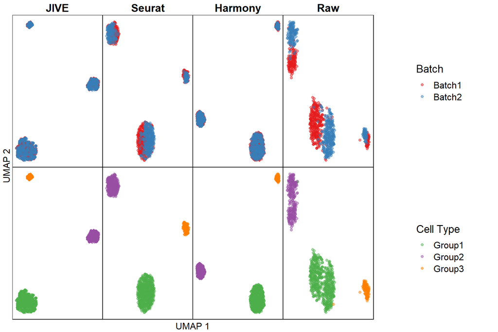

```r
# JIVE
jive_umap_df <- reducedDim(jive_integrated, "UMAP") %>%
  as.data.frame() %>%
  mutate(Method = "JIVE") %>%
  mutate(Batch = batches, Cluster = clusters)

jive_umap_batch <- jive_umap_df %>%
  ggplot(aes(x = V1, y = V2, color = Batch)) +
  geom_point(alpha = 0.5) +
  theme_nothing() +
  theme(
    plot.title = element_text(hjust = 0.5, face = "bold"),
    legend.position = "right",
    plot.background = element_rect(color = "black")
  ) +
  p1_options

jive_umap_cluster <- jive_umap_df %>%
  ggplot(aes(x = V1, y = V2, color = Cluster)) +
  geom_point(alpha = 0.5) +
  theme_nothing() +
  theme(
    legend.position = "right",
    plot.background = element_rect(color = "black")
  ) +
  p2_options

jive_title <- ggdraw() + draw_label("JIVE", fontface = "bold")

jive_umap_plot <- plot_grid(
  jive_title,
  jive_umap_batch + theme(legend.position = "none"),
  jive_umap_cluster + theme(legend.position = "none"),
  ncol = 1, align = "hv", rel_heights=c(0.1, 1, 1)
)

# Seurat
seurat_umap_df <- Embeddings(seurat_integrated, "umap") %>%
  as.data.frame() %>%
  mutate(Method = "Seurat") %>%
  mutate(Batch = batches, Cluster = clusters)

seurat_umap_batch <- seurat_umap_df %>%
  ggplot(aes(x = UMAP_1, y = UMAP_2, color = Batch)) +
  geom_point(alpha = 0.5) +
  theme_nothing() +
  theme(
    plot.title = element_text(hjust = 0.5, face = "bold"),
    legend.position = "right",
    plot.background = element_rect(color = "black")
  ) +
  p1_options

seurat_umap_cluster <- seurat_umap_df %>%
  ggplot(aes(x = UMAP_1, y = UMAP_2, color = Cluster)) +
  geom_point(alpha = 0.5) +
  theme_nothing() +
  theme(
    legend.position = "right",
    plot.background = element_rect(color = "black")
  ) +
  p2_options

seurat_title <- ggdraw() + draw_label("Seurat", fontface = "bold")

seurat_umap_plot <- plot_grid(
  seurat_title,
  seurat_umap_batch + theme(legend.position = "none"),
  seurat_umap_cluster + theme(legend.position = "none"),
  ncol = 1, align = "hv", rel_heights = c(0.1, 1, 1)
)

# Harmony
harmony_umap_df <- reducedDim(harmony_integrated, "UMAP") %>%
  as.data.frame() %>%
  mutate(Method = "Harmony") %>%
  mutate(Batch = batches, Cluster = clusters)

harmony_umap_batch <- harmony_umap_df %>%
  ggplot(aes(x = V1, y = V2, color = Batch)) +
  geom_point(alpha = 0.5) +
  theme_nothing() +
  theme(
    plot.title = element_text(hjust = 0.5, face = "bold"),
    legend.position = "right",
    plot.background = element_rect(color = "black")
  ) +
  p1_options

harmony_umap_cluster <- harmony_umap_df %>%
  ggplot(aes(x = V1, y = V2, color = Cluster)) +
  geom_point(alpha = 0.5) +
  theme_nothing() +
  theme(
    legend.position = "right",
    plot.background = element_rect(color = "black")
  ) +
  p2_options

harmony_title <- ggdraw() + draw_label("Harmony", fontface = "bold")

harmony_umap_plot <- plot_grid(
  harmony_title,
  harmony_umap_batch + theme(legend.position = "none"),
  harmony_umap_cluster + theme(legend.position = "none"),
  ncol = 1, align = "hv", rel_heights=c(0.1, 1, 1)
)

# Raw
raw_umap_df <- reducedDim(data_SCE, "UMAP") %>%
  as.data.frame() %>%
  mutate(Method = "Raw") %>%
  mutate(Batch = batches, Cluster = clusters)

raw_umap_batch <- raw_umap_df %>%
  ggplot(aes(x = V1, y = V2, color = Batch)) +
  geom_point(alpha = 0.5) +
  theme_nothing() +
  theme(
    plot.title = element_text(hjust = 0.5, face = "bold"),
    legend.position = "right",
    plot.background = element_rect(color = "black")
  ) +
  p1_options

raw_umap_cluster <- raw_umap_df %>%
  ggplot(aes(x = V1, y = V2, color = Cluster)) +
  geom_point(alpha = 0.5) +
  theme_nothing() +
  theme(
    legend.position = "right",
    plot.background = element_rect(color = "black")
  ) +
  p2_options

raw_title <- ggdraw() + draw_label("Raw", fontface = "bold")

raw_umap_plot <- plot_grid(
  raw_title,
  raw_umap_batch + theme(legend.position = "none"),
  raw_umap_cluster + theme(legend.position = "none"),
  ncol = 1, align = "hv", rel_heights=c(0.1, 1, 1)
)

# All
legend_batch <- get_legend(
  # create some space to the left of the legend
  jive_umap_batch + theme(legend.box.margin = margin(0, 0, 0, 12))
)

legend_cluster <- get_legend(
  # create some space to the left of the legend
  jive_umap_cluster + theme(legend.box.margin = margin(0, 0, 0, 12))
)

umap_prow <- plot_grid(
  jive_umap_plot,
  seurat_umap_plot,
  harmony_umap_plot,
  raw_umap_plot,
  nrow = 1,
  hjust = -1
  )

umap_prow_grob <- arrangeGrob(
  umap_prow,
  left = textGrob("UMAP 2", rot = 90),
  bottom = textGrob("UMAP 1")
)

umap_legend_both <- plot_grid(legend_batch, legend_cluster, nrow = 2, align = "v")

all_umap_plot <- plot_grid(umap_prow_grob, umap_legend_both, rel_widths = c(3, 1))

all_umap_plot
```

```r
ggsave("output/umap_simdata.png", all_umap_plot, width = 9, height = 4, dpi = 600)
```

## kBET

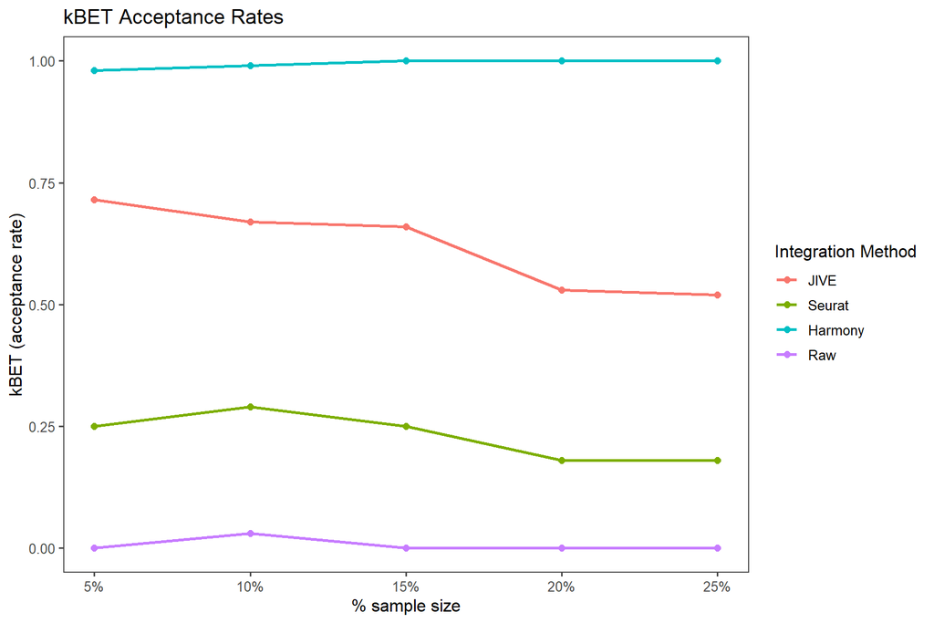

```r
all_kbet <- bind_rows(jive_kbet, seurat_kbet, harmony_kbet, raw_kbet) %>%
  mutate(Method = factor(Method, levels = method_lvl))

kbet_plot <- all_kbet %>%
  ggplot(aes(
    x = sample_size,
    y = I(1 - median_rr),
    group = Method,
    color = Method
  )) +  geom_line(linewidth = 1) +
  geom_point(size = 2) +
  scale_x_continuous(labels = scales::percent) +
  expand_limits(y = c(0, 1)) +
  labs(
    x = "% sample size",
    y = "kBET (acceptance rate)",
    color = "Integration Method"
    )

kbet_plot + labs(title = "kBET Acceptance Rates")
```

## Average Silhouette Width (ASW)

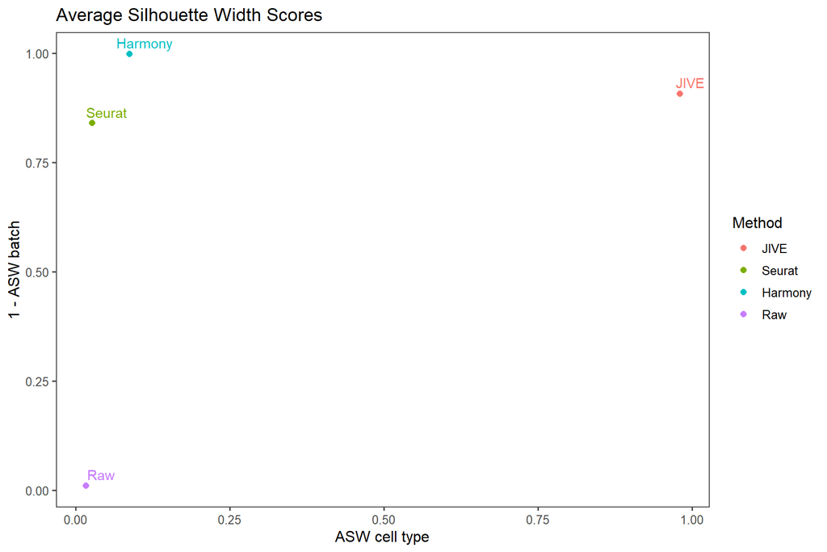

```r
all_asw <- bind_rows(jive_asw, seurat_asw, harmony_asw, raw_asw) %>%
  mutate(Method = factor(Method, levels = method_lvl))

asw_plot <- all_asw %>%
  group_by(Label) %>%
  mutate(Mean = scales::rescale(Mean)) %>%
  group_by(Method, Label) %>%
  summarize(median_ASW = median(Mean), .groups = "keep") %>%
  pivot_wider(
    id_cols = "Method",
    names_from = "Label",
    values_from = "median_ASW"
  ) %>%
  ggplot(aes(x = Cluster, y = I(1 - Batch), color = Method)) +
  geom_point(size = 2) +
  geom_text_repel(aes(label = Method), show.legend = FALSE) +
  labs(x = "ASW cell type", y = "1 - ASW batch")

asw_plot + labs(title = "Average Silhouette Width Scores")
```

## LISI Scores

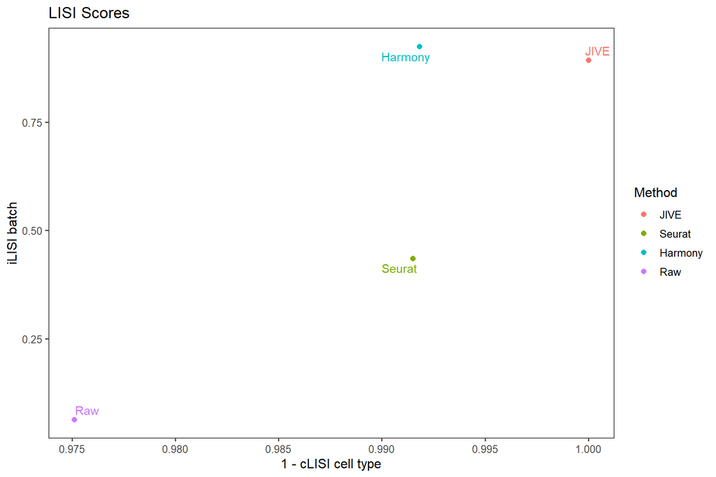

```r
all_lisi <- bind_rows(jive_lisi, seurat_lisi, harmony_lisi, raw_lisi) %>%
  mutate(Method = factor(Method, levels = method_lvl))

lisi_plot <- all_lisi %>%
  group_by(Label) %>%
  mutate(LISI = scales::rescale(LISI)) %>%
  group_by(Method, Label) %>%
  summarize(median_LISI = median(LISI), .groups = "keep") %>%
  pivot_wider(
    id_cols = "Method",
    names_from = "Label",
    values_from = "median_LISI"
  ) %>%
  ggplot(aes(x = I(1 - Cluster), y = Batch, color = Method)) +
  geom_point(size = 2) +
  geom_text_repel(aes(label = Method), show.legend = FALSE) +
  labs(x = "1 - cLISI cell type", y = "iLISI batch", )

lisi_plot + labs(title = "LISI Scores")
```

## All Metrics

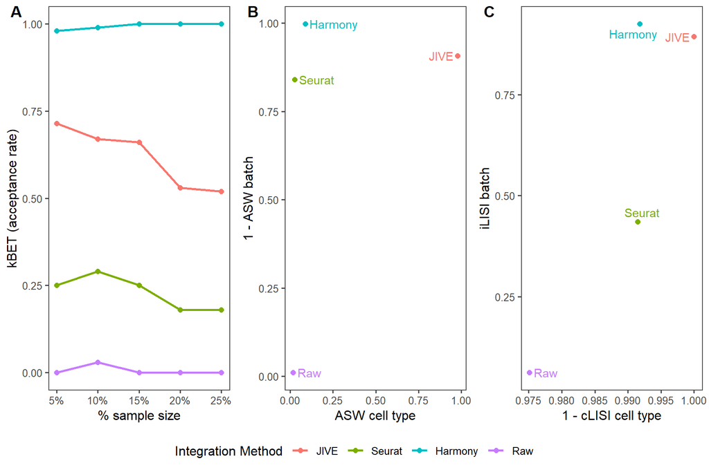

```r
# arrange the three plots in a single row
prow <- plot_grid(
  kbet_plot + theme(legend.position = "none"),
  asw_plot + theme(legend.position = "none"),
  lisi_plot + theme(legend.position = "none"),
  align = "hv",
  labels = c("A", "B", "C"),
  hjust = -1,
  nrow = 1
)

# extract the legend from one of the plots
legend <- get_legend(
  # create some space to the left of the legend
  kbet_plot + guides(color = guide_legend(nrow = 1)) + theme(legend.position = "bottom")
)

# add the legend to the row we made earlier. Give it one-third of
# the width of one plot (via rel_widths).
all_metrics_lot <- plot_grid(prow, legend, ncol = 1, rel_heights = c(1, .1))
all_metrics_lot
```

```r
ggsave("output/metrics_simdata.png", all_metrics_lot, width = 9, height = 4, dpi = 600)
```